# Sentinel 2

### Nori (Eleonora) Parelius

### 20.11.2023

# Sentinel 2

- Part of European Space Agency's (ESA) Copernicus programme
- Twin sattelites
  - Sentinel 2A since 23. June 2015
  - Sentinel 2B since 7. March 2017
  - Sentinel 2C, 2024?

[figure not shown]

## Coverage and time resolution

- At same angle every 5 days (10 days for same sattelite)
- Between $56^{\circ}$ S and $84^{\circ}$ degrees N
- Coast up to 20 km from land
- Islands over $100\ \rm{km^2}$
- Antarctica on demand
- Sun synchronous orbit at 786 km, 10:30 am descending node

[figure not shown]

  Image from Copernicus

## Sentinel 2 multispectral sensor

- 13 spectral bands in VIS, VNIR, SWIR
- Spatial resolution 10, 20, 60 m
- Push-broom, swath of 290 km

[figure not shown]

Image from eoportal.org

## Temporal offset

- Spectral bands image the surface at different times
- This offset creates "rainbows" for moving things

## Applications

- Agriculture and forestry
- Disaster mapping

## Sentinel tiles

[figure not shown]

Image from eox.at

## Products

All free!

- Level-1B
  - Top-of-atmosphere calibrated radiances in sensor geometry
  - Include radiometric corrections
  - Not orthorectified
  - Come in granules
- Level-1C
  - Top-of-atmosphere reflectance
  - Radiometrically and geometrically corrected
  - Orthorectified and spatially coregistered on a global reference system.
  - Come in tiles
- Level-2A
  - Bottom-of-atmosphere (Surface) reflectance
  - Otherwise same as L-1C

## Examples

# Sentinel 2 - Searching, downloading, loading up and working with it in Python

```python
import rasterio as rio
import geopandas as gpd
import shapely
import folium
import numpy as np
import matplotlib
import matplotlib.pyplot as plt
from matplotlib import cm
from sentinelhub import (
    SHConfig,
    CRS,
    BBox,
    DataCollection,
    SentinelHubCatalog,
    DownloadRequest,
    MimeType,
    MosaickingOrder,
    SentinelHubDownloadClient,
    SentinelHubRequest,
    bbox_to_dimensions,
    BBoxSplitter,
)
```

```python
%reload_ext autoreload
%autoreload 2
%matplotlib inline
```

## Authentication

You need to have a profile at Dataspace Copernicus, see README.md.

The following code cell creates a configuration file in `Users/UserName/.config/sentinelhub/config.toml` with the specified profile, here named `my-profile`, which contains the client id and secret. You only need to run this cell if you don't have a config file yet, otherwise just run the next one where the config file is loaded.

```python
# Running this cell creates a configuration file that can be called later.
# Only run this cell if you have not yet created a configuration.

#config = SHConfig()
#config.sh_client_id='<your client id>' # enter your id here
#config.sh_client_secret='<your client secret>' # enter your secret here
#config.sh_token_url = "https://identity.dataspace.copernicus.eu/auth/realms/CDSE/protocol/openid-connect/token"
#config.sh_base_url = "https://sh.dataspace.copernicus.eu"
#config.save("my-profile")
#config
```

```python
# If you already have a configuration, run this
config = SHConfig("my-profile")
```

## Area of interest

```python
nes_bbox_coords = (11.35, 60, 11.8, 60.21)
resolution = 10
nes_bbox = BBox(bbox=nes_bbox_coords, crs=CRS.WGS84)
nes_size = bbox_to_dimensions(nes_bbox, resolution=resolution)

print(f"Image shape at {resolution} m resolution: {nes_size} pixels.")
```

[output not shown]

```python
nes_polygon = shapely.geometry.box(11.35, 60, 11.8, 60.21)
poly_gdf = gpd.GeoDataFrame([1],geometry=[nes_polygon], crs="EPSG:4326")
```

```python
my_map = folium.Map([60.15,11.5], zoom_start=9)
folium.GeoJson(nes_polygon).add_to(my_map)
```

```
<folium.features.GeoJson at 0x2a57225a1e0>
```

```python
my_map
```

Make this Notebook Trusted to load map: File -> Trust Notebook

[interactive chart not shown]

## Getting a list of available images with SentinelHub Catalog API

```python
# Initializing the Catalog API
catalog = SentinelHubCatalog(config=config)
```

```python
def search_catalog(time_interval, bbox, cloud_cover):
    # Searching for the results with desired properties
    # Inputs:
    # time_interval - tuple of time points
    # bbox - bounding box of the area
    # cloud_cover - desired max cloud cover
    # Returns: search_iterator
    search_iterator = catalog.search(
        DataCollection.SENTINEL2_L2A,
        bbox=bbox,
        time=time_interval,
        filter="eo:cloud_cover < {}".format(cloud_cover),
        fields={"include": ["id", "properties.datetime"], "exclude": []},
    )
    return search_iterator
```

```python
# Time interval
time_interval_2021 = "2021-05-01", "2021-05-31"
time_interval_2022 = "2022-05-01", "2022-05-31"
cloud_cover = 1

results_2021 = list(search_catalog(time_interval_2021, nes_bbox, cloud_cover))
results_2022 = list(search_catalog(time_interval_2022, nes_bbox, cloud_cover))

results_2021
```

```
[{'id': 'S2B_MSIL2A_20210530T104619_N0500_R051_T32VPM_20230228T112003.SAFE',
  'properties': {'datetime': '2021-05-30T10:54:11.683Z'}},
 {'id': 'S2B_MSIL2A_20210530T104619_N0500_R051_T33VUG_20230228T112003.SAFE',
  'properties': {'datetime': '2021-05-30T10:54:07.817Z'}},
 {'id': 'S2A_MSIL2A_20210529T103021_N0500_R108_T32VPM_20230209T022319.SAFE',
  'properties': {'datetime': '2021-05-29T10:34:17.416Z'}},
 {'id': 'S2A_MSIL2A_20210529T103021_N0500_R108_T33VUG_20230209T022319.SAFE',
  'properties': {'datetime': '2021-05-29T10:34:15.692Z'}}]
```

```python
results_2022
```

```
[{'id': 'S2A_MSIL2A_20220517T103631_N0400_R008_T32VPM_20220517T161111.SAFE',
  'properties': {'datetime': '2022-05-17T10:44:19.563Z'}},
 {'id': 'S2A_MSIL2A_20220517T103631_N0400_R008_T33VUG_20220517T161111.SAFE',
  'properties': {'datetime': '2022-05-17T10:44:17.64Z'}}]
```

```python
time_2021 = results_2021[0].get('properties').get('datetime')[:10]
time_2022 = results_2022[0].get('properties').get('datetime')[:10]
```

## Downloading using SentinelHub Process API

```python
# The evalscript is a function written in Javascript which defines what kind of processing
# is done with the data before downloading it.
# Here we simply get all the bands.
evalscript_all_bands = """
    //VERSION=3
    function setup() {
        return {
            input: [{
                bands: ["B01","B02","B03","B04","B05","B06","B07","B08","B8A","B09","B11","B12"],
                units: "DN"
            }],
            output: {
                bands: 12,
                sampleType: "INT16"
            }
        };
    }

    function evaluatePixel(sample) {
        return [sample.B01,
                sample.B02,
                sample.B03,
                sample.B04,
                sample.B05,
                sample.B06,
                sample.B07,
                sample.B08,
                sample.B8A,
                sample.B09,
                sample.B11,
                sample.B12];
    }
"""
```

```python
# By default we can only request one image at a time, by giving the time interval we want.
# But we can also use the catalog search results to choose the image
request_all_bands_2021 = SentinelHubRequest(
    evalscript=evalscript_all_bands,
    input_data=[
        SentinelHubRequest.input_data(
            data_collection=DataCollection.SENTINEL2_L2A.define_from(
                "s2l2a", service_url=config.sh_base_url
            ),
            time_interval=(time_2021, time_2021),
            # this allows to create an image composed of
            # the least cloudy images in the chosen time frame
            #mosaicking_order=MosaickingOrder.LEAST_CC,
        )
    ],
    data_folder = time_2021,
    responses=[SentinelHubRequest.output_response("default", MimeType.TIFF)],
    bbox=nes_bbox,
    size=nes_size,
    config=config,
)
```

```python
# By default we can only request one image at a time, by giving the time interval we want.
# But we can also use the catalog search results to choose the image
request_all_bands_2022 = SentinelHubRequest(
    evalscript=evalscript_all_bands,
    input_data=[
        SentinelHubRequest.input_data(
            data_collection=DataCollection.SENTINEL2_L2A.define_from(
                "s2l2a", service_url=config.sh_base_url
            ),
            time_interval=(time_2022, time_2022),
            # this allows to create an image composed of
            # the least cloudy images in the chosen time frame
            #mosaicking_order=MosaickingOrder.LEAST_CC,
        )
    ],
    data_folder = time_2022,
    responses=[SentinelHubRequest.output_response("default", MimeType.TIFF)],
    bbox=nes_bbox,
    size=nes_size,
    config=config,
)
```

```python
all_bands_2021 = request_all_bands_2021.save_data()
all_bands_2022 = request_all_bands_2022.save_data()
```

## Loading the Geotiffs

```python
im_2021 = rio.open(time_2021+"/response.tiff")
im_2022 = rio.open(time_2022+"/response.tiff")

print(im_2021.shape)
print(im_2022.shape)
print(im_2021.crs)
```

```
(2435, 2410)
(2435, 2410)
EPSG:4326
```

## Plot one band

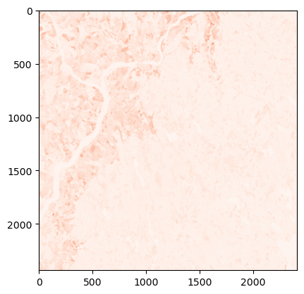

```python
plt.imshow(im_2021.read(4), cmap = cm.Reds)
```

## Plotting RGB images

```python
red_2021 = im_2021.read(4)
red_2021_norm = red_2021/np.max(red_2021)/0.5
green_2021 = im_2021.read(3)
green_2021_norm = green_2021/np.max(green_2021)/0.5
blue_2021 = im_2021.read(2)
blue_2021_norm = blue_2021/np.max(blue_2021)/0.5

red_2022 = im_2022.read(4)
red_2022_norm = red_2022/np.max(red_2022)/0.5
green_2022 = im_2022.read(3)
green_2022_norm = green_2022/np.max(green_2022)/0.5
blue_2022 = im_2022.read(2)
blue_2022_norm = blue_2022/np.max(blue_2022)/0.5
```

```
Clipping input data to the valid range for imshow with RGB data ([0..1] for floats or [0..255] for integers).
Clipping input data to the valid range for imshow with RGB data ([0..1] for floats or [0..255] for integers).
```

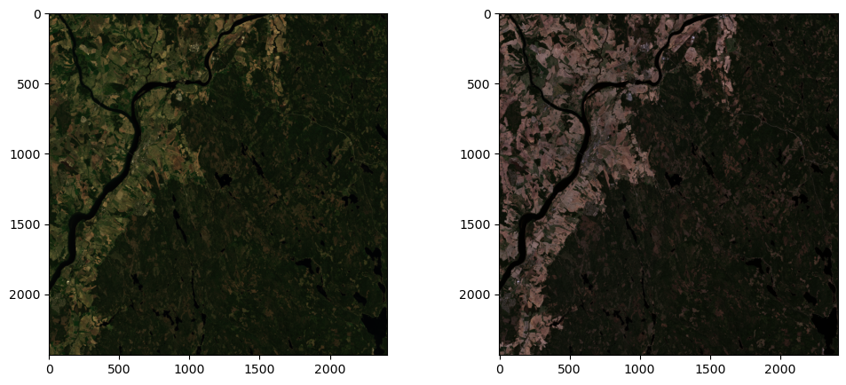

```python
fig, ax = plt.subplots(1,2, figsize=(12,5))
ax[0].imshow(np.dstack([red_2021_norm, green_2021_norm, blue_2021_norm]))
ax[1].imshow(np.dstack([red_2022_norm, green_2022_norm, blue_2022_norm]))
```

## NDVI images

```python
nir_2021 = im_2021.read(8)
nir_2022 = im_2022.read(8)

ndvi_2021 = (nir_2021-red_2021)/(nir_2021+red_2021)
ndvi_2022 = (nir_2022-red_2022)/(nir_2022+red_2022)
```

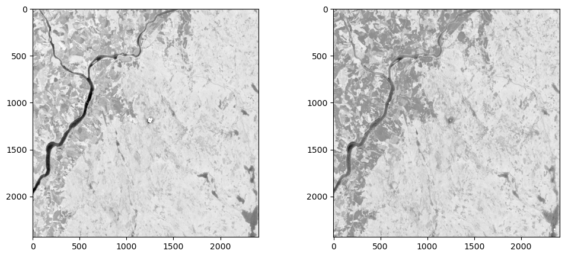

```python
fig, ax = plt.subplots(1,2, figsize=(12,5))
ax[0].imshow(ndvi_2021, cmap=cm.grey)
ax[1].imshow(ndvi_2022, cmap=cm.grey)
```

## Let's look at the difference

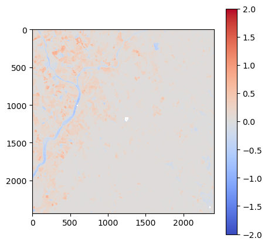

```python
diff = ndvi_2021 - ndvi_2022
fig, ax = plt.subplots(1, figsize=(5,5))
pic = ax.imshow(diff, norm=matplotlib.colors.CenteredNorm(),cmap = cm.coolwarm)
fig.colorbar(pic, ax=ax)
```

## Save the NDVI difference as a Geotiff

```python
with rio.open('2021-05-30/response.tiff') as src:
    out_image = diff
    out_meta = src.meta.copy()
    out_meta.update({
        "driver": "GTiff",
        "count": 1,
        "dtype": "float64",
    })
with rio.open("NDVI_diff.tiff", "w", **out_meta) as dest:
    dest.write(diff, indexes=1)
```

[output not shown]

[output not shown]

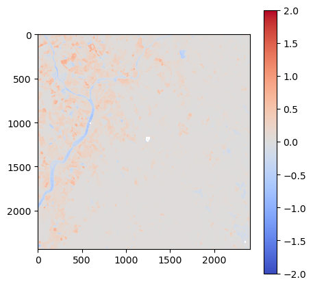

```python
diff_again = rio.open("NDVI_diff.tiff").read(1)
fig, ax = plt.subplots(1, figsize=(5,5))
pic = ax.imshow(diff_again, norm=matplotlib.colors.CenteredNorm(),cmap = cm.coolwarm)
fig.colorbar(pic, ax=ax)
```